# Лабараторная работа №4

Александр Повколас

29 Ноября, 2018

# Задание 1

## Генерация и простейшие статистики

Вывести первые **10** и последние **20** сгенерированных значений. Вывести минимальный и максимальный элементы, выборочные оценки математического ожидания, дисперсии, медианы, коэффициентов асимметрии и эксцесса, **25%** и **75%** - квантилей, **95%** - квантиля. Сравнить полученные оценки с теоретическими значениями. Построить ящик с *усами (диаграмма размаха)*, *эмпирическую функцию распределения*. Построить *выборочную гистограмму* и поверх нее *теоретическую плотность распределения*.

```
## [1] "First 10"
```

```
##  [1] -1.80612991 -0.79946905  0.00795623  2.51540163 -1.89519060
##  [6] -0.42952848  1.27284592 -2.33196636  1.09911084 -1.05836166
```

```
## [1] "Last 20"
```

```
##  [1]  0.4694728  1.8246355  2.5963299 -0.9340757  1.5453215 -2.8805930
##  [7]  2.4407380  0.2719105  0.5541349 -0.4891326 -1.9344117 -0.6516759
## [13] -1.3405866 -0.8491305  0.5305121  3.1483932 -0.9794871  4.0331945
## [19]  0.6623466  0.2130723
```

```
##      Min.   1st Qu.    Median      Mean   3rd Qu.      Max.       Var
## -6.707320 -1.321191  0.034985  0.003140  1.340656  7.093925  4.024413
##  Skewness  Kurtosis    95% Qu
##  0.004343  3.062290  3.392048
```

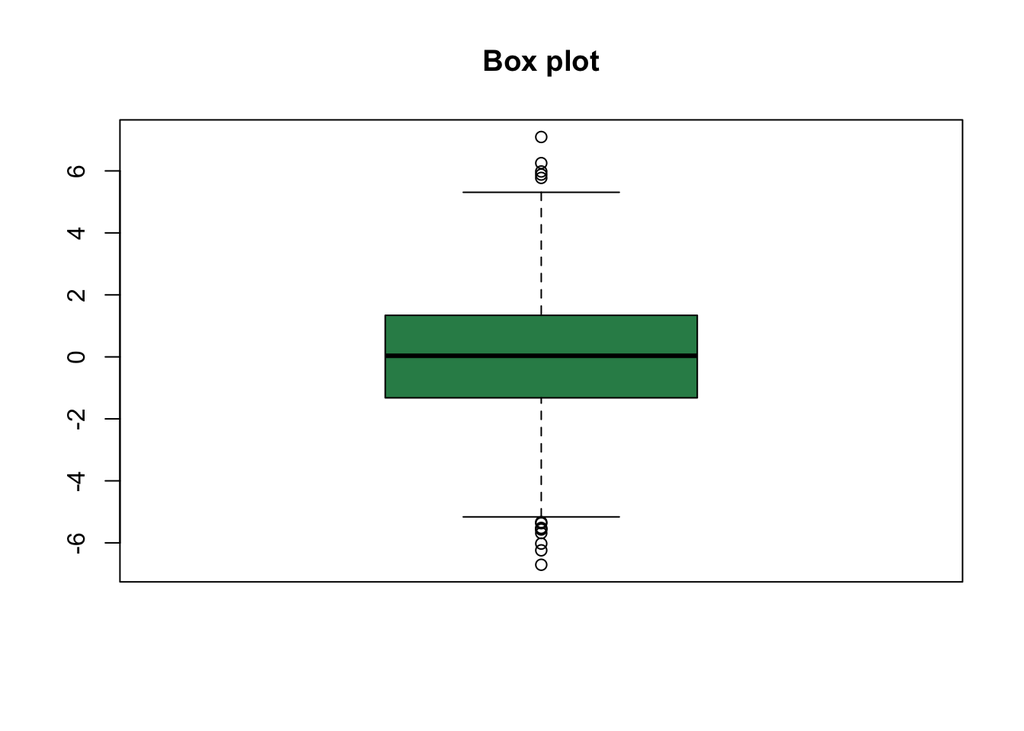

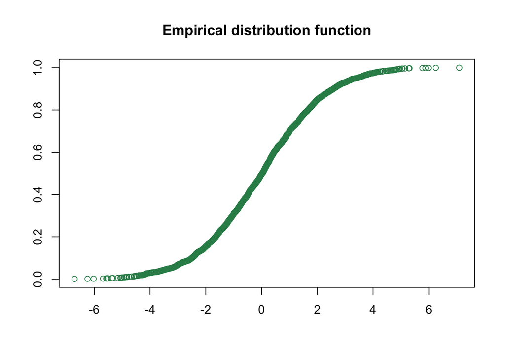

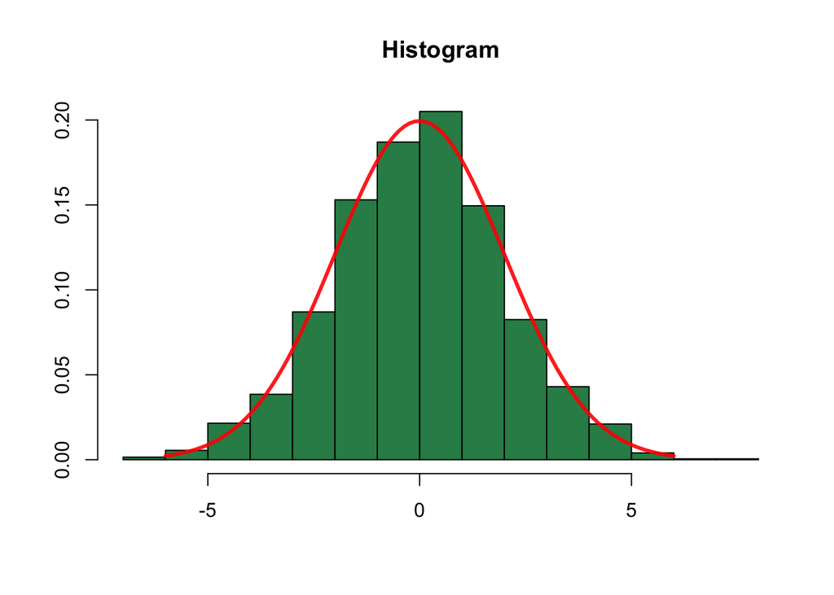

# Задание 2

## Проверка гипотез

Применяя известные вам тесты согласия (как минимум 2), проверить, что ранее сгенерированная вами выборка согласуется с вашим распределением. Сгенерировать выборку из любого из соседних вариантов, проверить, что новые данные плохо согласуется с распределением из вашего варианта. Одним из тестов согласия проверить гипотезу о том, что две выборки (из задания 1 и новая) принадлежат одному закону распределения

```r
shapiro.test(y)
```

```
##
##  Shapiro-Wilk normality test
##
## data:  y
## W = 0.99934, p-value = 0.7352
```

```r
ks.test(y,"pnorm", 0, 2)
```

```
##
##  One-sample Kolmogorov-Smirnov test
##
## data:  y
## D = 0.012414, p-value = 0.9175
## alternative hypothesis: two-sided
```

```r
ks.test(y,"pexp", 0.25)
```

```
##
##  One-sample Kolmogorov-Smirnov test
##
## data:  y
## D = 0.49587, p-value < 2.2e-16
## alternative hypothesis: two-sided
```

# Задание 3

## Проверка гипотез

Сгенерировать 1000 выборок из вашего варианта, для каждой из них проверить гипотезу о принадлежности к распределению из вашего варианта. Вывести для скольких выборок гипотеза была отвергнута.

```r
size <- 200
count <- 1000
negative <- 0
p.value <- 0.1

for(i in 1:count) {
  res <- ks.test(rnorm(size, mean = 0, sd = 2), "pnorm", 0, 2)
  if (res[2] < p.value ) {
      negative <- negative + 1
  }
}

cat("Negative: ", negative / count, "%")
```

```
## Negative:  0.095 %
```

# Задание 4

## User-friendly проверка гипотез согласия

Написать функцию, которая на вход принимает выборку и уровень значимости, проверяет согласованность выборки с распределением из вашего варианта, а на выход выдает текст в стиле “при заданном уровне значимости 0.05 гипотеза о принадлежности выборки к нормальному закону распределения принимается/отвергается”.

```
## [1] "rnorm(100, 0, 2)"
```

```
##
##  One-sample Kolmogorov-Smirnov test
##
## data:  x
## D = 0.071545, p-value = 0.6854
## alternative hypothesis: two-sided
##
## При заданном уровне значимости  0.1 гипотеза о принадлежности выборки к нормальному закону распределения принимается
```

```
## [1] "rexp(100, 2)"
```

```
##
##  One-sample Kolmogorov-Smirnov test
##
## data:  x
## D = 0.50189, p-value < 2.2e-16
## alternative hypothesis: two-sided
##
## При заданном уровне значимости  0.1 гипотеза о принадлежности выборки к нормальному закону распределения отвергается
```

```
## [1] "runif(100, 0, 1)"
```

```
##
##  One-sample Kolmogorov-Smirnov test
##
## data:  x
## D = 0.50158, p-value < 2.2e-16
## alternative hypothesis: two-sided
##
## При заданном уровне значимости  0.1 гипотеза о принадлежности выборки к нормальному закону распределения отвергается
```

## References

Ширяев, А.Н. 1980. “Вероятность. в 2-х кн.” 7 (2). М.: Наука: 179–88. http://booksshare.net/books/physics/shiryaev-an/1957/files/veroyatnost1957.pdf.